# Part 1 - Python?

# What is Python?

[Python](http://www.python.org) is a modern, general-purpose, object-oriented, high-level programming language.

- Created in 1990 by Guido van Rossum
- Name comes from Monty Python
- Generalized programming language (No specific discipline)
- Open source – free
- Cross-platform

## Interpreted

no need to compile the code (vs: C, Fortran)

## Dynamically typed

No need to define the type of variables. Variables can change meaning on-the-fly.

```python
my_var = 42
type(my_var)
```

```
int
```

```python
my_var = 'hello world'
type(my_var)
```

```
str
```

## High-level

Abstraction from the way the machine actually executes

## Easy to learn syntax (emphasizes readability)

- Python was designed to be a highly readable language.
- Python uses indentation to delimit program blocks (for loop, if, functions, etc) instead of punctuation or keywords
- It has a relatively uncluttered visual layout and uses English keywords frequently

"Good code shouldn’t just work. Good code should be easily understood by others who will need to work with it–including your future self."

[Software Engineering for Data Scientists](http://hiphoff.com/software-engineering-for-data-scientists/)

## "The Zen of Python"

- Python aims towards simplicity and generality in the design of its syntax

```python
import this
```

```
The Zen of Python, by Tim Peters

Beautiful is better than ugly.
Explicit is better than implicit.
Simple is better than complex.
Complex is better than complicated.
Flat is better than nested.
Sparse is better than dense.
Readability counts.
Special cases aren't special enough to break the rules.
Although practicality beats purity.
Errors should never pass silently.
Unless explicitly silenced.
In the face of ambiguity, refuse the temptation to guess.
There should be one-- and preferably only one --obvious way to do it.
Although that way may not be obvious at first unless you're Dutch.
Now is better than never.
Although never is often better than *right* now.
If the implementation is hard to explain, it's a bad idea.
If the implementation is easy to explain, it may be a good idea.
Namespaces are one honking great idea -- let's do more of those!
```

## Object-Oriented

- Modular, good for packaging and code re-use
- --> Huge number of available libraries: very used for scientific purposes and data analysis.

## Open-Source

- Python and its extensive standard library is available in source or binary form without charge for all major platforms, and can be freely distributed.
- Same for mathematics and science-oriented libraries.

# Why should I care?

## Python is suitable for scientific computing

- Python has a strong position in scientific computing:
  - Large community of users, easy to find help and documentation.
  - Extensive ecosystem of scientific libraries and environments
  - Close integration with time-tested and highly optimized codes written in C and Fortran --> Great performances
  - Good support for parallel, distributed and GPU computing
- No licence cost --> Budget can be use for something else...

## Cons:

- Developement decentralized, with different environment, packages and documentation spread out at different places --> Can make it harder to get started and find help.
- Interpreted and dynamically typed language --> execution of python code can be slow compared to compiled statically typed programming languages (C and Fortran).

[figure not shown]

## Python Scientific Ecosystem

[figure not shown]

from http://www.pyzo.org/python_vs_matlab.html

# Python at IRFM

[figure not shown]

## Linux

Connect on one of the following server with the NX client and your linux login and password:

- nashira
- merope

Once connected, open a terminal and first type :

```
module load python
```

This will setup your command line to use Python3 with the latest version of the Python numerical librairies (instead of old Python2 deprecated versions).

## Windows

Under windows, Python and all its scientific ecosystem is installed by default. You will find it here:

- start (démarrer) -> All programs (tous les programmes) -> WinPython

# Python Terminal.

Python itself is *interpreter*: it translates the Pyton source code into instructions that your computer understand. [1]

- Linux: open a terminal and type `python`. It display some informations and returns a `>>>` prompt.

```
[JH218595@merope ~ ]> python
Python 3.3.5 (default, Jul 22 2014, 09:44:27)
[GCC 4.4.6 20120305 (Red Hat 4.4.6-4)] on linu`
Type "help", "copyright", "credits" or "license" for more information.

Imported NumPy 1.8.1, SciPy 0.14.0, Matplotlib 1.3.1, pywed 0.1.1

Type "scientific" for more details.
>>>
```

To exit, use `exit()` or `CRTL+D` keyboard shortcut.

# IPython

IPython (stands for *Interactive Python*) is a more user-friendly Python interpreter.

- Linux: in a terminal, type `ipython`.
- Windows: IPython Qt Console.

```
[JH218595@merope ~ ]> ipython
Python 3.3.5 (default, Jul 22 2014, 09:44:27)
Type "copyright", "credits" or "license" for more information.

IPython 2.1.0 -- An enhanced Interactive Python.
?         -> Introduction and overview of IPython's features.
%quickref -> Quick reference.
help      -> Python's own help system.
object?   -> Details about 'object', use 'object??' for extra details.

Imported NumPy 1.8.1, SciPy 0.14.0, Matplotlib 1.3.1, pywed 0.1.1

Type "scientific" for more details.

In [1]:
```

# Jupyter (ex-IPython Notebook)

IPython comes with a web-browser based interface: the notebook.

The notebook allows one to mix text, equations ($\LaTeX$) or images, with Python code and graphics output. It is a great interface for explorary codes. (It has a similar look&feel than Mathematica notebook.). (These slides have been made with the notebook.)

A notebook can be used to document a computational work as a narrative way, with a direct access to the data.

The project has recently been renammed [Jupyter](http://jupyter.org/), as it allows to use other language than Python itself.

- Linux: in a terminal type `ipython notebook`
- Windows: IPython Notebook

[figure not shown]

A very nice equation with some $x$ and $ \infty$ : $$e^{i\pi} + \int_{-\infty}^{+\infty} e^{-a x^2} dx$$

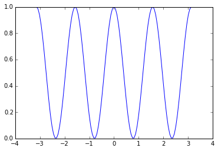

```python
# and now some code and graphics
x = linspace(-pi, +pi, 101)
y = cos(2*x)**2
plot(x,y)
```

# Spyder

Spyder (*Scientific PYthon Development EnviRonment*) is a powerful interactive development environment for the Python language with advanced editing, interactive testing, debugging and help features

Its interface look very much like the one of Matlab.

[figure not shown]

# Need help?

## IRFM Mailing list

Public maling list concerning python at IRFM: PyIRFM

- **`pyirfm@saxifrage.saclay.cea.fr`**

Suscribe here : http://saxifrage:3500/wws/subscribe/pyirfm

## IRFM Python Wiki

[figure not shown]

## Built-in commands

- `help(object)`: Prints documentation of the object

```python
help(46)
```

```
Help on int object:

class int(object)
 |  int(x=0) -> int or long
 |  int(x, base=10) -> int or long
 |  Convert a number or string to an integer, or return 0 if no arguments
 |  are given.  If x is floating point, the conversion truncates towards zero.
 |  If x is outside the integer range, the function returns a long instead.
 |  If x is not a number or if base is given, then x must be a string or
 |  Unicode object representing an integer literal in the given base.  The
 |  literal can be preceded by '+' or '-' and be surrounded by whitespace.
 |  The base defaults to 10.  Valid bases are 0 and 2-36.  Base 0 means to
 |  interpret the base from the string as an integer literal.
 |  >>> int('0b100', base=0)
 |  4
 |  Methods defined here:
 |  __abs__(...)
 |      x.__abs__() <==> abs(x)
 |  __add__(...)
 |      x.__add__(y) <==> x+y
 |  __and__(...)
 |      x.__and__(y) <==> x&y
 |  __cmp__(...)
 |      x.__cmp__(y) <==> cmp(x,y)
 |  __coerce__(...)
 |      x.__coerce__(y) <==> coerce(x, y)
 |  __div__(...)
 |      x.__div__(y) <==> x/y
 |  __divmod__(...)
 |      x.__divmod__(y) <==> divmod(x, y)
 |  __float__(...)
 |      x.__float__() <==> float(x)
 |  __floordiv__(...)
 |      x.__floordiv__(y) <==> x//y
 |  __format__(...)
 |  __getattribute__(...)
 |      x.__getattribute__('name') <==> x.name
 |  __getnewargs__(...)
 |  __hash__(...)
 |      x.__hash__() <==> hash(x)
```

[output cut: 78 more lines]

```
 |      Returns self, the complex conjugate of any int.
 |  ----------------------------------------------------------------------
 |  Data descriptors defined here:
 |  denominator
 |      the denominator of a rational number in lowest terms
 |  imag
 |      the imaginary part of a complex number
 |  numerator
 |      the numerator of a rational number in lowest terms
 |  real
 |      the real part of a complex number
 |  ----------------------------------------------------------------------
 |  Data and other attributes defined here:
 |  __new__ = <built-in method __new__ of type object>
 |      T.__new__(S, ...) -> a new object with type S, a subtype of T
```

- `dir(object)`: Prints valid attributes of object

```python
dir(42)
```

```
['__abs__',
 '__add__',
 '__and__',
 '__class__',
 '__cmp__',
 '__coerce__',
 '__delattr__',
 '__div__',
 '__divmod__',
 '__doc__',
 '__float__',
 '__floordiv__',
 '__format__',
 '__getattribute__',
 '__getnewargs__',
 '__hash__',
 '__hex__',
 '__index__',
 '__init__',
 '__int__',
 '__invert__',
 '__long__',
 '__lshift__',
 '__mod__',
 '__mul__',
 '__neg__',
 '__new__',
 '__nonzero__',
 '__oct__',
 '__or__',
 '__pos__',
 '__pow__',
 '__radd__',
 '__rand__',
 '__rdiv__',
 '__rdivmod__',
 '__reduce__',
 '__reduce_ex__',
 '__repr__',
 '__rfloordiv__',
```

[output cut: 9 more lines]

```
 '__rxor__',
 '__setattr__',
 '__sizeof__',
 '__str__',
 '__sub__',
 '__subclasshook__',
 '__truediv__',
 '__trunc__',
 '__xor__',
 'bit_length',
 'conjugate',
 'denominator',
 'imag',
 'numerator',
 'real']
```

## IPython additional commands

IPython offers additional commands which improve user experience.

- `an_object?`: Prints all known information about object
- `an_object??`: Shows source code where object is implemented
- Tab-completion: press tab and see what is available

`who` and `whos` are the same than in Matlab:

```python
idx = 10
test = 'youpi'
alist = [1,2,3]
```

```python
whos
```

```
Variable      Type        Data/Info
-----------------------------------
HTML          type        <class 'IPython.core.display.HTML'>
alist         list        n=3
css_styling   function    <function css_styling at 0x0000000007453C80>
idx           int         10
os            module      <module 'os' from 'C:\\Us<...>3.4.3.amd64\\lib\\os.py'>
test          str         youpi
this          module      <module 'this' from 'C:\\<...>4.3.amd64\\lib\\this.py'>
utils         module      <module 'IPython.utils' f<...>hon\\utils\\__init__.py'>
x             ndarray     101: 101 elems, type `float64`, 808 bytes
y             ndarray     101: 101 elems, type `float64`, 808 bytes
```